# Project 3: STAT302project3 Analysis

Leqi Wang & Oscar Bai

```r
library(tidyverse)
library(ggplot2)
my_gapminder <- read.csv("../Data/my_gapminder.csv")
my_penguins <- read.csv("../Data/my_penguins.csv")
my_t.test <- source("../Code/my_t.test.R")$value
my_lm <- source("../Code/my_lm.R")$value
my_knn_cv <- source("../Code/my_knn_cv.R")$value
my_rf_cv <- source("../Code/my_rf_cv.R")$value
```

# Introduction

This package includes 4 functions: `my_t.test`, `my_lm`, `my_knn_cv` and `my_rf_cv`, which are either for prediction or inference. First, we install the package from github and load the package using ‘library()’.

```r
devtools::install_github("wang-leqi/STAT302proj3")
```

```r
library(STAT302proj3)
```

# Tutorial for my_t.test

In this section, we set up a tutorial for my_t.test, we use the `lifeExp` data from `my_gapminder` to test a null hypothesis test.

```r
#hypothesis: mean of the life Expectancy from my_gapminder equals to 60(p-value cut-off of α=0.05)
#alternative hypothesis: mean of the life Expectancy data from my_gapminder does not equal to 60
val1 <- my_t_test(x=(my_gapminder$lifeExp),alternative="two sided",mu = 60)$p_value

#hypothesis: mean of the life Expectancy data from my_gapminder equals to 60(p-value cut-off of α=0.05)
#alternative hypothesis: mean of the life Expectancy data from my_gapminder is larger than 60
val2 <- my_t_test(x=(my_gapminder$lifeExp),alternative="greater",mu = 60)$p_value

#hypothesis: mean of the life Expectancy from my_gapminder equals to 60(p-value cut-off of α=0.05)
#alternative hypothesis: mean of the life Expectancy from my_gapminder is smaller than 60
val3 <- my_t_test(x=(my_gapminder$lifeExp),alternative="less",mu = 60)$p_value
```

For the first t-test, we observe P = 0.0932288, which is greater than cut off value. Thus we don’t have sufficient evidence to reject the null hypothesis and we can’t conclude that the mean life expectancy is equal to 60.

# Tutorial for my_lm

In this section, we generate a regression using life Expectancy as our response variable and gdp Percaption and continent as explanatory variables.

```r
result <- my_lm(lifeExp ~gdpPercap + continent, data = my_gapminder)
result_p <- result$`Pr(>|t|)`
result_gdp <- result_p[2]
result
```

```
## $Estimate
##                           [,1]
## (Intercept)       4.788852e+01
## gdpPercap         4.452704e-04
## continentAmericas 1.359272e+01
## continentAsia     8.657793e+00
## continentEurope   1.757234e+01
## continentOceania  1.814604e+01
##
## $`Std. Error`
##       (Intercept)         gdpPercap continentAmericas     continentAsia
##      3.398053e-01      2.349795e-05      6.007856e-01      5.554859e-01
##   continentEurope  continentOceania
##      6.257430e-01      1.787426e+00
##
## $`t value`
##                        [,1]
## (Intercept)       140.92927
## gdpPercap          18.94933
## continentAmericas  22.62491
## continentAsia      15.58598
## continentEurope    28.08236
## continentOceania   10.15205
##
## $`Pr(>|t|)`
##                            [,1]
## (Intercept)        0.000000e+00
## gdpPercap          8.552893e-73
## continentAmericas  2.822476e-99
## continentAsia      2.719424e-51
## continentEurope   7.595526e-143
## continentOceania   1.502557e-23
```

we see a positive coefficients for numeric variable gdpPercap, and therefore we say higher values of GDP may lead to higher life expectancy at birth. For variable continent, we find that different continents have different coefficients, so we expect a correlation between continent and life expectancy at birth.

```r
result_p
```

```
##                            [,1]
## (Intercept)        0.000000e+00
## gdpPercap          8.552893e-73
## continentAmericas  2.822476e-99
## continentAsia      2.719424e-51
## continentEurope   7.595526e-143
## continentOceania   1.502557e-23
```

As we can see, the p-value for gdpPercap is 8.5528931^{-73} and is significantly smaller than the cut off value. Therefore we can reject the null hypothesis that there is no correlation between `gdpPercap` and `lifeExp`. Below, we plot out the result based on a linear regression:

```r
mu <- result_p
#Write the hypothesis test associated with the gdpPercap coefficient.
my_t_test(x= my_gapminder$gdpPercap, alternative="less", mu)
```

```
## $test_stat
##                       [,1]
## (Intercept)       30.21524
## gdpPercap         30.21524
## continentAmericas 30.21524
## continentAsia     30.21524
## continentEurope   30.21524
## continentOceania  30.21524
##
## $df
## [1] 1703
##
## $p_value
##                            [,1]
## (Intercept)       3.017528e-161
## gdpPercap         3.017528e-161
## continentAmericas 3.017528e-161
## continentAsia     3.017528e-161
## continentEurope   3.017528e-161
## continentOceania  3.017528e-161
##
## $alternative
## [1] "less"
```

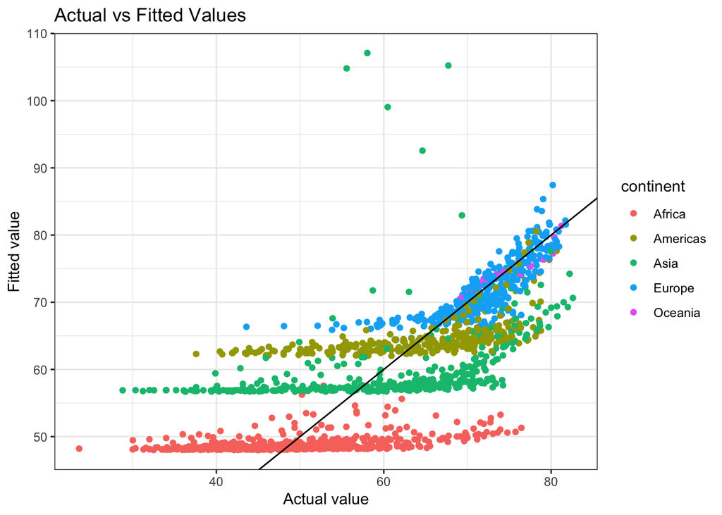

```r
#predict the fitted values
my_estimate <- result$Estimate
matrix <- model.matrix(lifeExp ~gdpPercap + continent, data = my_gapminder)
y_hat <- matrix %*% as.matrix(my_estimate)
df <- data.frame("actual" = my_gapminder$lifeExp, "fitted" = y_hat, "continent" = my_gapminder$continent)
#plot the Actual against Fitted values.

x <- my_gapminder$gdpPercap
y <- df$y_hat
fitting_plot <- ggplot(df, aes(x=x, y=y, color = continent)) +
        ggtitle(label = "Actual vs Fitted Values") +
        geom_point(aes(x = actual, y = fitted)) +
        xlab(label = "Actual value") +
        ylab(label = "Fitted value") +
        geom_abline(slope = 1, intercept = 0) +
        theme_bw()
        # geom_line(aes(x = x, y = fitted, col="Fitted value",lwd = 0.1))
        # labs(subtitle = paste("Testing Error:", round(test_err_k, 3))) +
        # theme_bw()
ggsave("plot1.jpg", path = "../Output/Figures")
fitting_plot
```

Interpret the Actual vs. Fitted values plot: The model is not optimal. As the x-axis represents the actual lines, and the y axis represents the fitted value. The slope of the line would represent the percent of precision of the fitted value to the actual values. Here, the slope of the graph does not appear to be straight, which means that this model fit is not optimal.

# Tutorial for my_knn_cv

```r
#A tutorial for my_knn_cv using my_penguins.
my_table <- data.frame()
my_penguins <- na.omit(my_penguins)
for(i in 1:10) {
  my_result <- my_knn_cv(train = my_penguins, cl = my_penguins$species, k_nn = i, k_cv = 5 )
  my_table[1,i] <- my_result$cv_err
  my_table[2,i] <- sum(as.numeric(my_penguins$species != my_result$class)) / nrow(my_penguins)
}
colnames(my_table) <- c("k_nn = 1", "k_nn = 2", "k_nn = 3", "k_nn = 4", "k_nn = 5", "k_nn = 6", "k_nn = 7", "k_nn = 8", "k_nn = 9", "k_nn = 10")
rownames(my_table) <- c("cv_err", "training_err")
my_table
```

```
##               k_nn = 1   k_nn = 2   k_nn = 3  k_nn = 4  k_nn = 5  k_nn = 6
## cv_err       0.1591592 0.22822823 0.20720721 0.2192192 0.2372372 0.2282282
## training_err 0.0000000 0.06606607 0.08108108 0.1381381 0.1561562 0.1651652
##               k_nn = 7  k_nn = 8  k_nn = 9 k_nn = 10
## cv_err       0.2102102 0.2132132 0.2102102 0.2252252
## training_err 0.1561562 0.1741742 0.1771772 0.1921922
```

In the table, when k_nn = 1, there are both the smallest cv error and the training error, so k_nn = 1 is the best model when k_cv = 5. Cross validation is a statistical method that used to check how accurately our model can predict the result.

# Tutorial for my_rf_cv

In this section, we predict body_mass_g using covariates bill_length_mm, bill_depth_mm, and flipper_length_mm using randomForest model.

```r
#Calculate CV estimated MSE when k = 2, 5, and 10
mat <- matrix(NA, nrow = 90, ncol = 2)
for (k in c(2, 5, 10)){
  for (i in 1:30) {
    mat[k %/% 5 * 30 + i, 1] <- k
    mat[k %/% 5 * 30 + i, 2] <- my_rf_cv(k)
  }
}
colnames(mat) <- c("k", "mse")
saveRDS(mat, file = "../Output/Results/mse.RDS")
```

Then we plot the result out with average CV estimate and standard deviation using boxplot across different k value.

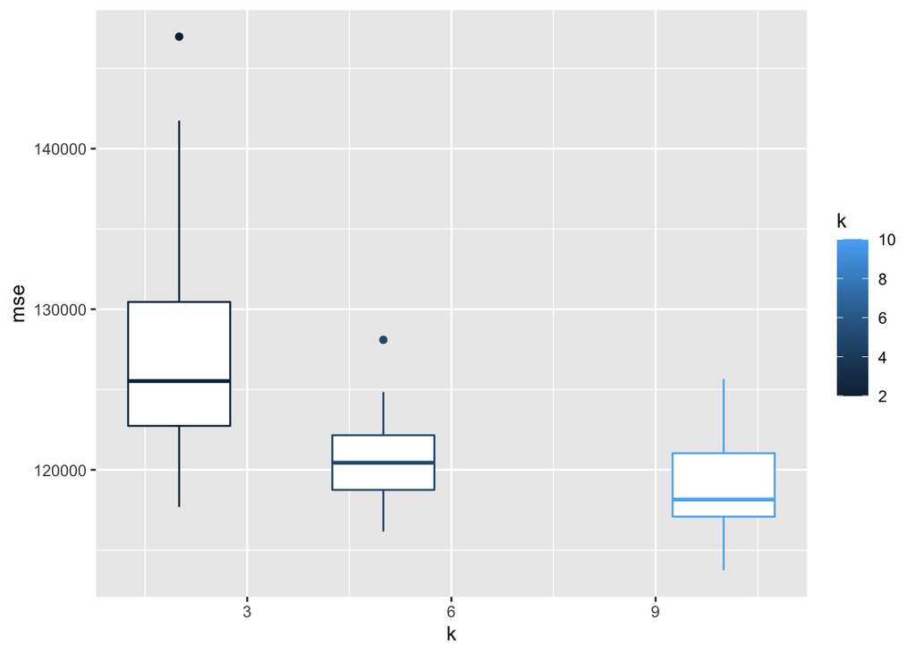

```r
#Generate a boxplot of MSE for multiple values of k.
data.frame(mat) %>%
  ggplot(aes(group = k, y = mse)) +
  geom_boxplot(aes(x = k, color = k)) +
  xlab("k")
```

```r
ggsave("plot2.jpg", path = "../Output/Figures")
tab <- matrix(NA, nrow = 3, ncol = 2)
rownames(tab) <- c("k = 2", "k = 5", "k = 10")
colnames(tab) <- c("mean", "sd")
tab[1, 1] <- mean(mat[1:30, 2])
tab[1, 2] <- sd(mat[1:30, 2])
tab[2, 1] <- mean(mat[31:60, 2])
tab[2, 2] <- sd(mat[31:60, 2])
tab[3, 1] <- mean(mat[61:90, 2])
tab[3, 2] <- sd(mat[61:90, 2])
tab
```

```
##            mean       sd
## k = 2  126796.0 6626.203
## k = 5  120625.6 2765.775
## k = 10 119021.2 2893.067
```

```r
write_csv(as.data.frame(tab), file = "../Output/Results/summary.csv")
```